# Python Take-home Exercise

**test_score = [10, 32, 23, 14, 25]**

```python
test_score = [10, 32, 23, 14, 25]

# initially set the sum to 0
sum=0
for i in range(len(test_score)-1):
       sum = sum + test_score[i]
print('Sum =',sum)
```

```
Sum = 79
```

### 11. Find the minimum value along each of the rows

Create a 2D Numpy array from list of lists

Score = np.array([[210, 402, 383],  
[140, 375, 106],  
[140, 125, 217],  
[292, 240, 295]])

```python
# import numpy
import numpy as np

Score = np.array([[210, 402, 383],
[140, 375, 106],
[140, 125, 217],
[292, 240, 295]])

# np.amin(): return the minimum of the array
# axis=1: it stands for row in np.amin()
min_value = np.amin(Score, axis=1)

# print the result
print('min value of every row: ', min_value)
```

```
min value of every row:  [210 106 125 240]
```

### 12. Replace all even numbers in the array with -1

Use the array given below

```
num_array = np.array([0, 21, 32, 13, 44, 45, 26, 28, 38, 34, 65, 48, 76])
```

```python
num_array = np.array([0, 21, 32, 13, 44, 45, 26, 28, 38, 34, 65, 48, 76])

# use condition 'arr % 2 == 0' to replace all odd numbers
num_array[num_array % 2 == 0] = -1

# print the result
num_array
```

```
array([-1, 21, -1, 13, -1, 45, -1, -1, -1, -1, 65, -1, -1])
```

### 13. Create a pandas series having values 4, 8, -1, 2, NAN and their index as d, b, a, c, e

```python
# import pandas
import pandas as pd

# creating a new series
my_series = pd.Series([4, 8, -1, 2, np.nan], index=['d', 'b', 'a', 'c',"e"])

# printing the newly created series
print(my_series)
```

```
d    4.0
b    8.0
a   -1.0
c    2.0
e    NaN
dtype: float64
```

### 14. Add a new column 'Height' in the give dataframe

| Name | Weight |
| --- | --- |
| Mia | 55 |
| Joy | 66 |
| Karan | 80 |
| George | 67 |

New Column:

| Height |
| --- |
| 5.5 |
| 6.7 |
| 5.8 |
| 6 |

```python
# Creating a dictionary
student_dict = {
       "Name":["Mia","Joy","Karan","George"],
       "Weight":[55, 66, 80, 67]
}

# converting the dictionary into a dataframe
df_student = pd.DataFrame(student_dict)

# printing the dataframe
print(df_student)
```

```
     Name  Weight
0     Mia      55
1     Joy      66
2   Karan      80
3  George      67
```

```python
# add a new column 'Height'
# if a list is assigned to a column, then its elements become the values of that column
df_student['Height'] = [5.5, 6.7, 5.8, 6]

# printing the dataframe
print(df_student)
```

```
     Name  Weight  Height
0     Mia      55     5.5
1     Joy      66     6.7
2   Karan      80     5.8
3  George      67     6.0
```

### 15. Use the data created in question 14, to do the following:

Access column 'Name' by specifying the column number  
Access column 'Height' by specifying the column name

```python
# 1. Access column 'Name' by specifying the column number.

# iloc() works on index positions. Here we are accessing the column with index position 0 i.e. column 'Name'
df_student.iloc[:,0]
```

```
0       Mia
1       Joy
2     Karan
3    George
Name: Name, dtype: object
```

```python
# 2. Access column 'Height' by specifying the column name.

# accessing a column by directly calling it
df_student.Height
# OR
# accessing a column by passing the column names inside the square brackets
df_student["Height"]

# Use any one command
```

```
0    5.5
1    6.7
2    5.8
3    6.0
Name: Height, dtype: float64
```

### 16. Find duplicate rows based on the column 'Order_ID'

**Use the dataframe given below:**

| Order_ID | Product | City |
| --- | --- | --- |
| YZ1100 | Cell Phone | Sydeny |
| RW1200 | Watch | Chicago |
| YZ1100 | Cell Phone | New York |
| TY1400 | Charger | Chicago |
| VB1500 | Watch | Chicago |
| TY1400 | Headphones | Texas |
| MW1600 | Charger | New York |
| CN1600 | Headphones | Chicago |

```python
# store the data
product = [('YZ1100', 'Cell Phone', 'Sydeny'),
('RW1200', 'Watch', 'Chicago'),
('YZ1100', 'Cell Phone', 'New York'),
('TY1400', 'Charger', 'Chicago'),
('VB1500', 'Watch', 'Chicago'),
('TY1400', 'Headphones', 'Texas'),
('MW1600', 'Charger', 'New York'),
('CN1600', 'Headphones', 'Chicago')]

# Create a dataframe
df_products= pd.DataFrame(product, columns=['Order_ID', 'Product', 'City'])

# print the data
df_products
```

|  | Order_ID | Product | City |
| --- | --- | --- | --- |
| 0 | YZ1100 | Cell Phone | Sydeny |
| 1 | RW1200 | Watch | Chicago |
| 2 | YZ1100 | Cell Phone | New York |
| 3 | TY1400 | Charger | Chicago |
| 4 | VB1500 | Watch | Chicago |
| 5 | TY1400 | Headphones | Texas |
| 6 | MW1600 | Charger | New York |
| 7 | CN1600 | Headphones | Chicago |

```python
# duplicate rows based on one column
df_duplicate_rows = df_products[df_products.duplicated(['Order_ID'])]
# print the result
print("Following are the duplicate rows based on a single column:", df_duplicate_rows, sep='\n')
```

```
Following are the duplicate rows based on a single column:
  Order_ID     Product      City
2   YZ1100  Cell Phone  New York
5   TY1400  Headphones     Texas
```

### 17. Use the data created in question 16, to do the following:

In column 'Product', replace all the 'Cell Phone' values with 'Mobile' using numpy.where

```python
# replace the values using np.where()
df_products['Product'] = np.where((df_products.Product == 'Cell Phone'),'Mobile',df_products.Product)
# print the dataframe
df_products
```

|  | Order_ID | Product | City |
| --- | --- | --- | --- |
| 0 | YZ1100 | Mobile | Sydeny |
| 1 | RW1200 | Watch | Chicago |
| 2 | YZ1100 | Mobile | New York |
| 3 | TY1400 | Charger | Chicago |
| 4 | VB1500 | Watch | Chicago |
| 5 | TY1400 | Headphones | Texas |
| 6 | MW1600 | Charger | New York |
| 7 | CN1600 | Headphones | Chicago |

### 18. Perform right join to combine values based on the 'ID' in the two dataframes

**Use the dataframe given below:**

[output not shown]

[output not shown]

```python
# create a dataframe
df_info_1 = pd.DataFrame({
'ID':[101,102,103,104,105,106,107],
'Candidate_Name': ['Alex', 'Amy', 'Allen', 'Alice', 'James', 'Sara', 'Mia'],
'Subject':['History','English','Geography','German','History', 'German', 'English']})

# create a dataframe
df_info_2 = pd.DataFrame(
{'ID':[101,102,103,104,105,108],
'City': ['Delhi', 'Mumbai', 'Delhi', 'Chennai', 'Hyderabad','Delhi'],
'Subject_Score':[89,78,77,87,87,84]})

# print the data
print(df_info_1,'\n')
print(df_info_2)
```

```
    ID Candidate_Name    Subject
0  101           Alex    History
1  102            Amy    English
2  103          Allen  Geography
3  104          Alice     German
4  105          James    History
5  106           Sara     German
6  107            Mia    English

    ID       City  Subject_Score
0  101      Delhi             89
1  102     Mumbai             78
2  103      Delhi             77
3  104    Chennai             87
4  105  Hyderabad             87
5  108      Delhi             84
```

```python
# perform right join
df_right = pd.merge(df_info_1, df_info_2, on=['ID'], how='right')
# print the dataframe
df_right
```

|  | ID | Candidate_Name | Subject | City | Subject_Score |
| --- | --- | --- | --- | --- | --- |
| 0 | 101 | Alex | History | Delhi | 89 |
| 1 | 102 | Amy | English | Mumbai | 78 |
| 2 | 103 | Allen | Geography | Delhi | 77 |
| 3 | 104 | Alice | German | Chennai | 87 |
| 4 | 105 | James | History | Hyderabad | 87 |
| 5 | 108 | NaN | NaN | Delhi | 84 |

### 19. Use the following data to plot a pie chart and annotate the percentage sales

[output not shown]

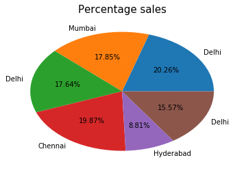

```python
import matplotlib.pyplot as plt

# create an array of sales and location
sales = np.array([890, 784,775, 873, 387, 684])
city = ['Delhi','Mumbai','Delhi','Chennai',"Hyderabad","Delhi"]

# plot a pie chart
# autopct: give the proportion of wedge in percentage
plt.pie(sales,labels = city, autopct= '%1.2f%%' )

# set the plot title
plt.title('Percentage sales', fontsize=15 )

# display the plot
plt.show()
```

### 20. Use the data created in question 19, to do the following:

Calculate minimum, maximum and average sales for each origin

```python
# create a dataframe
df_sales = pd.DataFrame({'City': ['Delhi','Mumbai','Delhi','Chennai',"Hyderabad","Delhi"],
'Sales': [890, 784,775, 873, 387, 684]})

# print the dataframe
df_sales
```

|  | City | Sales |
| --- | --- | --- |
| 0 | Delhi | 890 |
| 1 | Mumbai | 784 |
| 2 | Delhi | 775 |
| 3 | Chennai | 873 |
| 4 | Hyderabad | 387 |
| 5 | Delhi | 684 |

```python
# use groupby() method to group the dataframe by 'Seasons'.
# Then use agg() to find minimum, maximum, and average sales for each season
# min: finds the minimum values
# max: finds the maximum values
# mean: calculates the mean
df_grouped = df_sales.groupby('City').agg({'Sales':['min','max','mean']})
# print the dataframe
df_grouped
```

| City | Sales min | Sales max | Sales mean |
| --- | --- | --- | --- |
| Chennai | 873 | 873 | 873 |
| Delhi | 684 | 890 | 783 |
| Hyderabad | 387 | 387 | 387 |
| Mumbai | 784 | 784 | 784 |